# GroveCovering

## Groves of Covering Graphs

### 1. Some definitions

**Definition** Let $\Gamma=(V,E)$ be an undirected graph, and $F\subseteq E$ be a set of vertices of $\Gamma$, and let $P$ be a partition of $F$. Denote $\text{Gr}_{\Gamma}(P)$ the weighted sum of the set of groves which partitions the vertices in $F$ in the same way as $P$. See the first section of this paper https://arxiv.org/pdf/math/0608422.pdf.

Now let $\Gamma$ be a graph and $\tilde\Gamma$ be a $k$-fold covering graph of $\Gamma$. A cool fact about covering graph is that, every tree in $\Gamma$ will be lifted to $k$ different (connected) copies in $\tilde\Gamma$. For example, below is a graph and a $3$-fold cover:

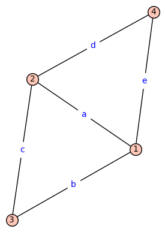

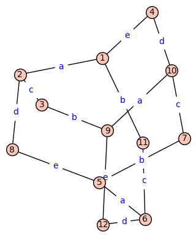

```python
G,CG=MakeCoveringGraph(make_graph(),K)
G.graphplot(edge_labels=True,layout='spring').show()
CG.graphplot(edge_labels=True,layout='spring').show()
```

As you can see, the tree $3-1-2-4$ (which is weighted $abd$ ), is lifted to three trees in the covering graph, $11-1-2-8$, $3-9-10-4$, and $7-5-6-12$.

This observation motivates the following small conjecture

**Conjecture 0** Let $T$ be a subtree in $\Gamma$ and $T_1,T_2,\cdots,T_k$ be its lifts in $\tilde\Gamma$. Consider any coloring of $T$, which induces a partition on vertices of $T$, call it $P$. The same coloring on $T_1,\cdots,T_k$ will again give us partitions similarly, call them $P_1,\cdots,P_k$. Then $$\text{Gr}_{\tilde\Gamma}(P_1)=\text{Gr}_{\tilde\Gamma}(P_2)=\cdots=\text{Gr}_{\tilde\Gamma}(P_k)$$

**Example** In the above graph, we have $\text{Gr}_{\tilde\Gamma}(11|1|2|8)=\text{Gr}_{\tilde\Gamma}(3|9|10|4)=\text{Gr}_{\tilde\Gamma}(7|5|6|12)$. Or a different partition: $\text{Gr}_{\tilde\Gamma}(11,2|1,8)=\text{Gr}_{\tilde\Gamma}(3,10|4,9)=\text{Gr}_{\tilde\Gamma}(7,6|5,12)$.

### 2. The main conjecture

**Conjecture 1** Let $T_1,T_2$ be subtrees in $\Gamma$ such that $T_1\subset T_2$. Let the vertices of $T_1$ be $\{a_1,\cdots,a_i\}$ and the vertices of $T_2$ be $\{a_1,\cdots,a_i,a_{i+1},\cdots,a_{i+j}$.

Let $T_1',T_2'$ be lifts of $T_1,T_2$ in $\tilde\Gamma$ respectively, WLOG (due to Conjeture 0) assume $T_1'\subset T_2'$. Let the vertices of $T_1$ be $\{a_1',\cdots,a_i'\}$ and the vertices of $T_2$ be $\{a_1',\cdots,a_i',a_{i+1}',\cdots,a_{i+j}'\}$.

Then we conjecture $$\frac{\text{Gr}_{\tilde\Gamma}(a_1'|a_2'|\cdots|a_{i+j}')}{\text{Gr}_{\Gamma}(a_1|a_2|\cdots|a_{i+j})} > \frac{\text{Gr}_{\tilde\Gamma}(a_1'|a_2'|\cdots|a_{i}')}{\text{Gr}_{\Gamma}(a_1|a_2|\cdots|a_{i})} $$ More specifically, the difference is a positive rational function.

**Remark** When $T_2$ is spanning tree, we should view the above expression as a product formula: $$\text{Gr}_{\tilde\Gamma}(a_1'|a_2'|\cdots|a_{i+j}')\cdot \text{Gr}_{\Gamma}(a_1|a_2|\cdots|a_{i})>\text{Gr}_{\Gamma}(a_1|a_2|\cdots|a_{i+j})\cdot \text{Gr}_{\tilde\Gamma}(a_1'|a_2'|\cdots|a_{i}')$$which is true because $\text{Gr}_{\Gamma}(a_1|a_2|\cdots|a_{i+j})=0$.

**Remark** When $T_2$ is an edge, and $T_1$ is a single vertex, the conjecture is equivalent to saying the resistance of $(i',j')$ is $\tilde\Gamma$ is larger than the resistance of $(i,j)$ in $\Gamma$ when $(i',j')$ is lift of $(i,j)$.

**Example** Use the same graph, and take $T_0=(3,1,2,4)$ and let: $T_1=(3,1,2), T_2=(1,2)$, $T_3=(1)$. In the covering graph lets take $T_0'=(11,1,2,8)$ and $T_1'=(11,1,2)$, $T_2'=(1,2)$, $T_3'=(1)$. Then the conjecture implies $$ \frac{\text{Gr}_{\tilde\Gamma}(11|1|2) }{\text{Gr}_{\Gamma}(3|1|2) }>\frac{\text{Gr}_{\tilde\Gamma}(1|2) }{\text{Gr}_{\Gamma}(1|2) }>\frac{\text{Trees of }{\tilde\Gamma} }{\text{Trees of }{\Gamma} } $$

### 3. Now let's check the conjecture

##### README

1. **Trees( G )** returns the weightes sum of trees in $G$
2. **SimpleGrove(G, List)** returnes the Groves of $G$ when the partition is non-crossing, e.g. $\texttt{SimpleGrove(G,[1,2,3]))}=\text{Gr}_{G}(1|2|3)$. (This is what the main conjecture is about.)
3. **Grove(G, partition)** returns the Groves of $G$ of arbitrary boundary partition, e.g. $\texttt{Grove(G,[{1},{2,4},{3}]))}=\text{Gr}_{G}(1|3|2,4)$.
4. **Resistance(G,i,j)** returns the resistance of $G$ between $i$ and $j$.
5. **IsPositive(P)** checks if a rational function is positive (in a naive way).

```python
#This is a block of functions
def Trees(graff):
    #The Arborescence of a graph rooted at vertex i
    v=len(graff.vertices())
    List=list(range(v))
    List.remove(0)
    L=graff.kirchhoff_matrix(indegree=False,weighted=True)
    A=L.matrix_from_rows_and_columns(List,List)
    return det(A).expand()

def SimpleGrove(G,BoundaryList):
    v=len(G.vertices())
    List=[]
    k=0
    for q in range(v):
        if k+1 not in BoundaryList:
            List+=[k]
        k+=1
    L=G.kirchhoff_matrix(indegree=False,weighted=True)
    A=L.matrix_from_rows_and_columns(List,List)
    return det(A).expand()

def Resistance(G,i,j):
    N=SimpleGrove(G,[i,j])
    D=Trees(G,i)
    OUT=N/D
    return OUT

#This is a function to compute Gr(P) which seems to be impossible to run on Cocalc.
def Grove(G,parti):
    grove=0
    v_partitions=SetPartitions(Set(G.vertices())).list()
    for v_parti in v_partitions:
        count=0
        forest_poly=1
        if len(v_parti)==len(parti):
            v_parti_list=list(v_parti)[:]
            for i in parti:
                subcount=0
                for j in v_parti_list:
                    if len(j)>0:
                        j=set(list(j))
                    else:
                        j={}
                    if i in Subsets(j).list():
                        subcount+=1
                        if j in v_parti_list:
                            v_parti_list.remove(j)
                if subcount>0:
                    count+=1
            if count==len(parti):
                for part in v_parti:
                    if len(part)>1:
                        tree_poly=0
                        subG=G.subgraph(list(part))
                        trees=subG.spanning_trees()
                        for tree in trees:
                            sub_tree_poly=1
                            for eg in tree.edges():
                                sub_tree_poly*=G.edge_label(eg[0],eg[1])
                            tree_poly+=sub_tree_poly
                    else:
                        tree_poly=1
                    forest_poly*=tree_poly
            else:
                forest_poly=0
        else:
            forest_poly=0
        grove+=forest_poly
    return grove

### Check if a polynomial/rational function is positive
def IsPositive(inp):
    InpS=str(inp.full_simplify())
    if '-' in InpS:
        return False
    else:
        return True
### Warning ###
### This is really a naive check and not gaurentee to work in general.
### If returned True, the input is definitely positive;
### But if returned False, the input could still be positive.
### What it does is simply simplify it and see if there is any - sign in the string.
```

##### README continued

1. Modify the following block to define a covering graph

```python
### Covering Graphs

#undirected version

K=3

#This will be a K-fold cover

def make_graph(perm=None):
    if perm != None:
    # You can ignore this, or
    # Use this if you want to use this input to range over different covers
        return [
   #((vertex,vertex,edge weight),permutation voltage)
    ((1,2,'a'),perm[0]),
    ((3,1,'d'),perm[1]),
    ((2,3,'c'),perm[2]),
    ((2,4,'d'),perm[3]),
    ((1,4,'e'),perm[4]),
]
    else:
    # Make your own graph here.
        return [
       #((vertex,vertex,edge weight),permutation voltage)
        ((1,2,'a'),[0,1,2]),
        ((3,1,'b'),[2,1,0]),
        ((2,3,'c'),[0,2,1]),
        ((2,4,'d'),[1,2,0]),
        ((1,4,'e'),[0,1,2]),
    ]
```

##### README continued

1. Then just use `MyGraph, myCoveringGraph = MakeCoveringGraph(makegraph(),K)`

```python
def MakeCoveringGraph(Input,K):
    theGraff={}
    theGraph=[]
    NoV=0
    NoE=0
    for A,P in Input:
        #print(A,P)
        w=var(A[2])
        X=(A[0],A[1],w)
        theGraff[X]=P
        theGraph+=[X]
        for i in [A[0],A[1]]:
            if i>= NoV:
                NoV=i
    mygraff=Graph(theGraph)
    CGraff=[]
    for i in range(K):
        for e,p in theGraff.items():
            #print(theGraff.items())
            a=e[0]+NoV*i
            b=e[1]+NoV*p[i]
            c=e[2]
            CGraff+=[(a,b,c)]
            #CGraff+=[(str(e[0])+','+str(i+1),str(e[1])+','+str(p[i]+1),c)]
    mycovergraff=Graph(CGraff)
    return mygraff,mycovergraff
```

Now make our covering graph again, this is the same as the above one.

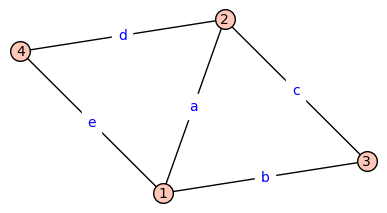

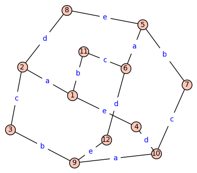

```python
G,CG=MakeCoveringGraph(make_graph(),K)
G.graphplot(edge_labels=True,layout='spring').show()
CG.graphplot(edge_labels=True,layout='spring').show()
```

Let's check the conjecture

```python
R0=Trees(CG)/Trees(G)
```

```python
R1=SimpleGrove(CG,[1,2])/SimpleGrove(G,[1,2])
```

```python
R2=SimpleGrove(CG,[11,1,2])/SimpleGrove(G,[3,1,2])
```

```python
print(IsPositive(R2-R1))
print(IsPositive(R1-R0))
print(IsPositive(R2-R0))
```

```
True
True
True
```

Here's another one.

```python
RR0=Trees(CG)/Trees(G)
RR1=SimpleGrove(CG,[9,10])/SimpleGrove(G,[1,2])
RR2=SimpleGrove(CG,[3,9,10])/SimpleGrove(G,[1,2,3])
```

```python
print(IsPositive(RR2-RR1))
print(IsPositive(RR1-RR0))
print(IsPositive(RR2-RR0))
```

```
True
True
True
```